# 02 Preprocessing and Analysis

Jennifer Frehn

4/25/2018

### Description of Script

This script loads, preprocesses and conducts descriptive text analysis on the datasets all_f.csv and all_m.csv. It then produces visualizations of the analysis.

### Set Working Directory

```r
setwd("/Users/JenniferF/Box Sync/Cal 2018 Spring Courses/jf_PS239T/Final Project Planning/R Files")
rm(list=ls())
```

### Load Packages

```r
require(tm) # Framework for text mining
require(ggplot2) # for plotting word frequencies
require(dplyr)
```

### Preparing Corpus

##### 1. Getting Sources and Readers

```r
getSources()
getReaders()
```

##### 2. Read in CSVs

Reading in csv, with each row being a document, and columns for text and metadata.

```r
all_f.df <-read.csv("all_f.csv", header=TRUE) #read in CSV file
doc_f <- Corpus(VectorSource(all_f.df$newplaintext))

all_m.df <-read.csv("all_m.csv", header=TRUE) #read in CSV file
doc_m <- Corpus(VectorSource(all_m.df$newplaintext))
```

##### 3. Sneak Peak at Docs

Below we can see the content of specific tweets.

```r
# # See the structure of the docs
# str(doc_f)  # Female doc structure
# str(doc_m)  # Male doc structure

# Inspect the 200th doc
# inspect(doc_f[200]) # For female doc
# inspect(doc_m[200]) # For male doc

 # See content for 280th document
as.character(doc_f[[280]]) # For female doc
```

```
## [1] "@NRA The 2 nd amendment can be amended also ! @nra are traitors that need to be shut down !"
```

```r
as.character(doc_m[[280]]) # For male doc
```

```
## [1] "Hang in there Bernie, your are a voice for humanity, sad that politicians don't see H factor."
```

### Preprocessing

##### Option 1: No Customization

The below instructions call DTM on the corpus, using the built in preprocessing steps, including the built in stopwords dictionary. You can leave any out or turn them false. We will be doing Option #2, further below.

```r
# dtm_f <- DocumentTermMatrix(doc_f,
#            control = list(tolower = TRUE,
#                           removePunctuation = TRUE,
#                           removeNumbers = TRUE,
#                           stopwords = TRUE,
#                           stemming=TRUE))
#
# dtm_m <- DocumentTermMatrix(doc_m,
#            control = list(tolower = TRUE,
#                           removePunctuation = TRUE,
#                           removeNumbers = TRUE,
#                           stopwords = TRUE,
#                           stemming=TRUE))
```

##### Option 2: Customization

The below instructions call DTM on the corpus, using **custom** preprocessing steps.

```r
# Custom Stopwords
## Creating a custom list of stopwords that exclude certain words by taking the difference between stopwords("en") and the list of words we want to exclude. In this case, we are excluding variations of the word "you" because we want to do analysis on words associated with the word "you" or variations of it.
exceptions <- c("you", "your", "youre", "yourself", "yourselves", "ur", "you're", "you've", "you'll")
my_stopwords <- setdiff(stopwords("en"), exceptions)

# Creating dataframe for females
dtm_f <- tm_map(doc_f, removePunctuation) # Removes punctuation
dtm_f <- tm_map(dtm_f, removeNumbers) # Removes numbers
dtm_f <- tm_map(dtm_f, content_transformer(tolower)) # Transforms content to lowercase
dtm_f <- tm_map(dtm_f, removeWords, my_stopwords) # Removes my custom stopwords, created above
dtm_f <- tm_map(dtm_f, removeWords, c("thedonald", "donald", "realdonaldtrump", "trump")) # Removes additional words
#dtm_f <- tm_map(dtm_f, stripWhitespace) # This strips white space. We did not do this step.
dtm_f <- tm_map(dtm_f, stemDocument) # Stems the words in the document

# Calls the DTM on the corpus (females), while setting the default customization arguments to false, because we already used custom preprocessing arguments
dtm_f <- DocumentTermMatrix(dtm_f,
           control = list(tolower = FALSE,
                          removePunctuation = FALSE,
                          removeNumbers = FALSE,
                          stopwords = FALSE,
                          stemming=FALSE))

# Creating dataframe for males
dtm_m <- tm_map(doc_m, removePunctuation) # Removes punctuation
dtm_m <- tm_map(dtm_m, removeNumbers) # Removes numbers
dtm_m <- tm_map(dtm_m, content_transformer(tolower)) # Transforms content to lowercase
dtm_m <- tm_map(dtm_m, removeWords, my_stopwords) # Removes my custom stopwords, created above
dtm_m <- tm_map(dtm_m, removeWords, c("thedonald", "donald", "realdonaldtrump", "trump")) # Removes additional words
#dtm_m <- tm_map(dtm_m, stripWhitespace) # This strips white space. We did not do this step.
dtm_m <- tm_map(dtm_m, stemDocument) # Stems the words in the document

# Calls the DTM on the corpus (males), while setting the default customization arguments to false, because we already used custom preprocessing arguments
dtm_m <- DocumentTermMatrix(dtm_m,
           control = list(tolower = FALSE,
                          removePunctuation = FALSE,
                          removeNumbers = FALSE,
                          stopwords = FALSE,
                          stemming = FALSE))
```

### Exploring DTM

Below show instructions for looking at the structure of the DTM, and taking a sneak peak at specific observations.

```r
# # Looking at the structure of our DTM.
# dim(dtm_f)
# dim(dtm_m)

# # Showing lines 1-5 for variables 800-810
# inspect(dtm_f[15:25,800:810])
# inspect(dtm_m[15:25,800:810])
```

### Setting Up Frequencies

Here we set up some basic frequencies to get a feel for the data.

```r
# We can obtain the term frequencies as a vector by converting the document term matrix into a matrix and summing the column counts
freq_f <- colSums(as.matrix(dtm_f)) # For females
freq_m <- colSums(as.matrix(dtm_m)) # For males

# By ordering the frequencies we can list the most frequent terms and the least frequent terms:
ord_f <- order(freq_f) # For females
ord_m <- order(freq_m) # For males

# Least frequent terms
# freq_f[head(ord_f, 20)] # For females
# freq_m[head(ord_m, 20)] # For males

# Most frequent
freq_f[tail(ord_f, 20)] # For females
```

```
##    right    money democrat     know      one     want   presid      can
##     2618     2636     2688     2702     2823     2996     3177     3184
##     vote american     just     need     like     will     dont    peopl
##     3205     3369     3613     3837     4037     4115     4291     4651
##      get    illeg     your      you
##     4670     5069    13895    35334
```

```r
freq_m[tail(ord_m, 20)] # For males
```

```
##         vote        senat          one      mueller          can
##         1318         1348         1384         1385         1448
## senatemajldr     american       presid         know     democrat
##         1560         1613         1675         1696         1757
##         need        chuck         like         dont         just
##         1819         1956         2071         2116         2133
##          get        peopl         will         your          you
##         2183         2233         2418         7806        20166
```

```r
# Frequency of frenquencies
# head(table(freq_f),15)  # For females
# tail(table(freq_f),15)  # For males
#
# head(table(freq_m),15)  # For females
# tail(table(freq_m),15)  # For males

# Plot of frequencies
# plot(table(freq_f))  # For females
# plot(table(freq_m))  # For males

# Use built in package to see what are the most frequent words. Here we are specifying that we want to see words that appear at least 100 times
# findFreqTerms(dtm_f, lowfreq=100) # For females
# findFreqTerms(dtm_m, lowfreq=100) # For males
```

### Exploring Associations

##### 1. Finding Associations

Below we are going to explore words that correlate with the word “you.” We are using 0.04 as a lower bound for the correlation. In the dtm, each row is a tweet sent to a senator. This result is saying, “when the word ‘you’ is in a tweet, these were the other words in that tweet.”

```r
# Words associated with "you" for females
findAssocs(dtm_f, "you", 0.04)
```

```
## $you
##         your         dont         know         want        think
##         0.24         0.15         0.14         0.12         0.11
##       presid         like     yourself         will          say
##         0.11         0.09         0.09         0.09         0.09
##        peopl         vote       repres         mean          see
##         0.08         0.08         0.08         0.08         0.08
##        thank         care     american          get       realiz
##         0.08         0.07         0.07         0.07         0.07
##         just         joke       realli      disgrac       resign
##         0.07         0.07         0.07         0.07         0.07
##          can         dare         kill         talk        shame
##         0.07         0.07         0.07         0.07         0.07
##        ellen        senat        illeg          tri          run
##         0.07         0.06         0.06         0.06         0.06
##         make          lie     hypocrit        potus      support
##         0.06         0.06         0.06         0.06         0.06
##         hope         cant        polit      citizen        offic
##         0.06         0.06         0.06         0.06         0.06
##   california     threaten         elev    constitut         come
##         0.06         0.06         0.06         0.05         0.05
##         show       stupid        never          one       someth
##         0.05         0.05         0.05         0.05         0.05
##         help      disgust         hate         sick       pathet
##         0.05         0.05         0.05         0.05         0.05
##         tell        anyth        funni         ever        tweet
##         0.05         0.05         0.05         0.05         0.05
##        didnt         look        speak         noth        arent
##         0.05         0.05         0.05         0.05         0.05
##        liber      dreamer      comment       believ        laugh
##         0.05         0.05         0.05         0.05         0.05
##      serious        mouth         wish        asham        chanc
##         0.05         0.05         0.05         0.05         0.05
##        offer    embarrass       kamala theellenshow         liar
##         0.05         0.05         0.05         0.05         0.04
##        right   understand        stand         even        might
##         0.04         0.04         0.04         0.04         0.04
##      countri       actual         give         said         mayb
##         0.04         0.04         0.04         0.04         0.04
##         oath          yet         done        idiot          pos
##         0.04         0.04         0.04         0.04         0.04
##     constitu       listen        sleep         daca         took
##         0.04         0.04         0.04         0.04         0.04
##       apolog         blew      franken
##         0.04         0.04         0.04
```

```r
# Words associated with "you" for males
findAssocs(dtm_m, "you", 0.04)
```

```
## $you
##       your       dont       know      think       want       like
##       0.26       0.16       0.13       0.12       0.11       0.11
##      peopl   yourself       will       just        sir       vote
##       0.10       0.10       0.09       0.09       0.09       0.09
##   question      thank        can   american     presid        see
##       0.09       0.08       0.08       0.08       0.08       0.08
##       noth       care      parti      obama        get     believ
##       0.08       0.08       0.07       0.07       0.07       0.07
##        say    primari       take      arent        tri       hate
##       0.07       0.07       0.07       0.07       0.07       0.07
##       cant     havent     realli        gay   democrat       hope
##       0.07       0.07       0.07       0.07       0.06       0.06
##      never       work    countri        dem    support       ever
##       0.06       0.06       0.06       0.06       0.06       0.06
##       tell        ask   hypocrit    disgrac        sex       make
##       0.06       0.06       0.06       0.06       0.06       0.05
##        way      asham        one        win       need       fool
##       0.05       0.05       0.05       0.05       0.05       0.05
##       give        lie       fuck      speak       time       help
##       0.05       0.05       0.05       0.05       0.05       0.05
##        run       done       said       lost      thing       youv
##       0.05       0.05       0.05       0.05       0.05       0.05
##      shame       year      anyth       shit       talk      sound
##       0.05       0.05       0.05       0.05       0.05       0.05
##     racist        sit      senat       hell     answer        god
##       0.05       0.05       0.05       0.05       0.05       0.05
##       daca        pos      chanc     muslim     pelosi      nanci
##       0.05       0.05       0.05       0.05       0.05       0.05
##      liber       live      stand    citizen       look       mayb
##       0.04       0.04       0.04       0.04       0.04       0.04
##       stop understand      heard       shut     someth      everi
##       0.04       0.04       0.04       0.04       0.04       0.04
##    america     stupid      mouth        man   unfortun      elect
##       0.04       0.04       0.04       0.04       0.04       0.04
##    everyth        hey      becom       damn       jerk       pray
##       0.04       0.04       0.04       0.04       0.04       0.04
##        guy       crap      offic     mirror      wrong     repres
##       0.04       0.04       0.04       0.04       0.04       0.04
##      posit      illeg  constitut      chuck
##       0.04       0.04       0.04       0.04
```

##### 2. Describing Association Results

I was interested in examining the differences in the positive and negative words associated with “you” for each group - female and male senators. In looking at the results, it does not seem that there are many words that could definitely be considered positive. However, there are many words that can definitely be considered negative. Below is a table showing the negative words most associated with “you” that Twitter users wrote in response to tweets from each group of senators. Words in bold are words that are unique to each list.

| Female Senators | Male Senators |
| --- | --- |
| **joke** | hate |
| disgrac | hypocrit |
| **resign** | disgrac |
| shame | asham |
| lie | **fool** |
| hypocrit | lie |
| stupid | **fuck** |
| **disgust** | shame |
| hate | **shit** |
| **sick** | **racist** |
| **pathet** | **hell** |
| mouth | pos |
| asham | **shut** |
| **embarrass** | stupid |
| **liar** | mouth |
| **idiot** | **damn** |
| pos | **jerk** |
| – | **crap** |
| – | **wrong** |

### Exploring Frequencies

Below we will make and save frequency bar graphs for each group (males and females).

```r
# Plot the most frequent words - Females
freq_female <- sort(colSums(as.matrix(dtm_f)),decreasing=TRUE) # Sorting
head(freq_female) # Shows highest frequency words
```

```
##   you  your illeg   get peopl  dont
## 35334 13895  5069  4670  4651  4291
```

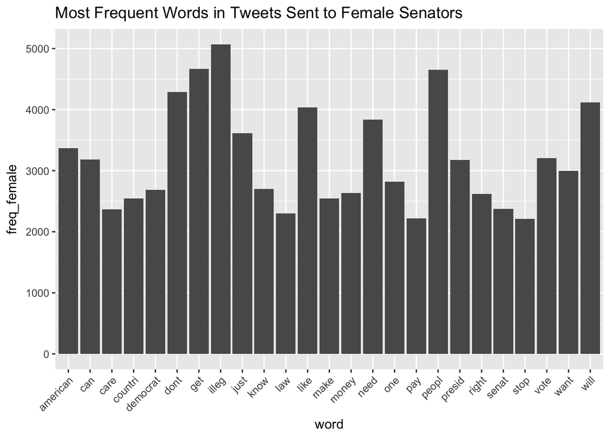

```r
wf_f <- data.frame(word=names(freq_female), freq_female=freq_female) # Creating dataframe
#head(wf_f) # Different way of showing highest frequency words

# The below instructions input a range so that "you" and "your" are not included
female_freq_graph <- subset(wf_f, freq_female>2200 & freq_female<6000) %>%
    ggplot(aes(word, freq_female)) +
        geom_bar (stat ="identity") +
        ggtitle("Most Frequent Words in Tweets Sent to Female Senators") +
        theme(axis.text.x=element_text(angle=45,hjust=1))

# Print graph - Females
female_freq_graph
```

```r
# Plot the most frequent words - Males
freq_male <- sort(colSums(as.matrix(dtm_m)),decreasing=TRUE) # Sorting
head(freq_male) # Shows highest frequency words
```

```
##   you  your  will peopl   get  just
## 20166  7806  2418  2233  2183  2133
```

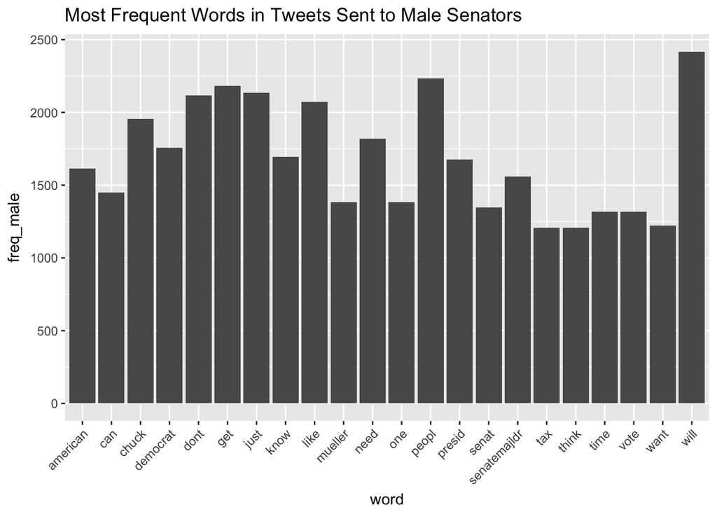

```r
wf_m <- data.frame(word=names(freq_male), freq_male=freq_male) # Creating dataframe
#head(wf_m) # Different way of showing highest frequency words

# The below instructions input a range so that "you" and "your" are not included
male_freq_graph <- subset(wf_m, freq_male>1200 & freq_male<5000) %>%
    ggplot(aes(word, freq_male)) +
        geom_bar (stat ="identity") +
        ggtitle("Most Frequent Words in Tweets Sent to Male Senators") +
        theme(axis.text.x=element_text(angle=45,hjust=1))

# Print graph - Males
male_freq_graph
```

```r
# Saving the graphs
ggsave(filename="female_freq_graph.png", plot=female_freq_graph, width = 7, height = 5)
ggsave(filename="male_freq_graph.png", plot=male_freq_graph, width = 7, height = 5)
```